# SF/SEA Summer 2014 Crime Data Analysis

Michael O’Dell

6/11/2017

```r
knitr::opts_chunk$set(echo = TRUE)

library(tidyverse)
library(lubridate)
library(ggplot2)
library(magrittr)
library(maps)

# load data
seattle <- read_csv(file = "seattle_incidents_summer_2014.csv")
sf <- read.csv(file = "sanfrancisco_incidents_summer_2014.csv", stringsAsFactors = FALSE)
```

## Comparing Two Cities

This post compares police reports from the Summer of 2014 in both **San Francisco** and **Seattle**. The data is from from the https://data.seattle.gov and https://datasf.org/opendata/ sites.

# Data Overview

Incident codes differ somewhat between the two cities. Thus in order to compare the two data sets, this report uses a combination of the indencent categories from the two cities incident categories from the two data sets mapped to the common set by matching key words from the `Offense Type` and `Summarized Offense Description` variables in the **Seattle** data and the `Category` and `Descript` variables in the **San Francisco** data.

The original **Seattle** data set contains over 1,000 incidents that were reported after August 31, 2014. These plus all *non-criminal* incidents from both cities are removed from the data sets. All other incidents are preserved albeit reclassified in some cases to the unified categories.

For spatial analysis, this report uses the reported longitude and latitude for each incident (the `Longitude` and `Latitude` Seattle variables and the `X` and `Y` San Francisco variables).

```r
sfs <- sf %>%
  select(
    Category,
    Descript,
    Date,
    Time,
    PdDistrict,
    X,
    Y,
    Address
  ) %>%
  mutate(
    Time = paste(Time, ":00", sep = ""),
    Date = mdy_hms(paste(Date, Time, sep = " "), tz = "PST8PDT")
  ) %>%
  rename(
    offense_type = Category,
    description = Descript,
    date = Date,
    district = PdDistrict,
    lon = X,
    lat = Y,
    block = Address
  ) %>%
  select(
    -Time
  )

sfs$city <- rep("San Francisco", nrow(sfs))

seattles <- seattle %>%
  select(
    `Offense Type`,
    `Summarized Offense Description`,
    `Date Reported`,
    `District/Sector`,
    Longitude,
    Latitude,
    `Hundred Block Location`
  ) %>%
  mutate(
    `Date Reported` = mdy_hms(`Date Reported`, tz = "PST8PDT")
  ) %>%
  rename(
    description = `Offense Type`,
    offense_type = `Summarized Offense Description`,
    date = `Date Reported`,
    district = `District/Sector`,
    lon = Longitude,
    lat = Latitude,
    block = `Hundred Block Location`
  )

seattles$city <- rep("Seattle", nrow(seattles))

## add 2014 population

seattle_pop <- 668324
sf_pop <- 852469
sfs$pop <- rep(sf_pop, nrow(sfs))
seattles$pop <- rep(seattle_pop, nrow(seattle))

sfsea <- rbind(sfs, seattles)

## sort incidents
sfsea$category <- sfsea$offense_type

sfsea$category <- gsub("BURGLARY-SECURE PARKING-RES", "BURGLARY", sfsea$category)
sfsea$category <- gsub("DRIVING UNDER THE INFLUENCE", "DUI", sfsea$category)
sfsea$category <- gsub("DRUG/NARCOTIC|NARCOTICS", "DRUGS", sfsea$category)
sfsea$category <- gsub("LIQUOR LAWS", "LIQUOR VIOLATION", sfsea$category)
sfsea$category <- gsub("PORNOGRAPHY/OBSCENE MAT", "PORNOGRAPHY", sfsea$category)
sfsea$category <- gsub("THREATS", "ASSAULT", sfsea$category)
sfsea$category <- gsub("WARRANT ARREST", "WARRANTS", sfsea$category)
sfsea$category <- gsub("VIOLATION OF COURT ORDER", "OTHER OFFENSES", sfsea$category)
sfsea$category <- gsub("WEAPON LAWS", "WEAPON", sfsea$category)
sfsea$category <- gsub("LARCENY/THEFT", "THEFT-LARCENY", sfsea$category)
sfsea$category <- gsub("MAIL THEFT", "THEFT-MAIL", sfsea$category)
sfsea$category <- gsub("CAR PROWL", "THEFT-VEHICLE", sfsea$category)
sfsea$category <- gsub("VEHICLE THEFT", "THEFT-VEHICLE", sfsea$category)
sfsea$category <- gsub("OTHER PROPERTY", "THEFT-LARCENY", sfsea$category)
sfsea$category <- gsub("BIKE THEFT", "THEFT-BIKE", sfsea$category)
sfsea$category <- gsub("SHOPLIFTING", "THEFT-LARCENY", sfsea$category)
sfsea$category <- gsub("PURSE SNATCH", "THEFT-LARCENY", sfsea$category)
sfsea$category <- gsub("PICKPOCKET", "THEFT-LARCENY", sfsea$category)
sfsea$category <- gsub("THEFT OF SERVICES", "THEFT-SERVICE", sfsea$category)
sfsea$category <- gsub("FORGERY$", "FORGERY/COUNTERFEITING", sfsea$category)
sfsea$category <- gsub("COUNTERFEIT$", "FORGERY/COUNTERFEITING", sfsea$category)
sfsea$category <- gsub("STOLEN PROPERTY", "PROPERTY-STOLEN", sfsea$category)
sfsea$category <- gsub("LOST PROPERTY", "NON-CRIMINAL", sfsea$category)
sfsea$category <- gsub("PROPERTY DAMAGE", "PROPERTY-DAMAGE", sfsea$category)
sfsea$category <- gsub("RECOVERED PROPERTY", "PROPERTY-RECOVERED", sfsea$category)
sfsea$category <- gsub("EMBEZZLE$", "EMBEZZLEMENT", sfsea$category)
sfsea$category <- gsub("INJURY", "ASSAULT", sfsea$category)
sfsea$category <- gsub("PUBLIC NUISANCE", "DISORDERLY CONDUCT", sfsea$category)
sfsea$category <- gsub("DISTURBANCE", "DISORDERLY CONDUCT", sfsea$category)
sfsea$category <- gsub("BURGLARY", "THEFT-LARCENY", sfsea$category)
sfsea$category <- gsub("^THEFT-LARCENY$", "THEFT-LARCENY-BURGLARY", sfsea$category)


# reclassify based on description
sfsea %<>%
  mutate(
    category = ifelse(grepl("DOMESTIC VIOLENCE", description), "ASSAULT", category),
    category = ifelse(grepl("GANG ACTIVITY", description), "GANG ACTIVITY", category),
    category = ifelse(grepl("ATM RELATED CRIME", description), "ATM RELATED CRIME", category),
    category = ifelse(grepl("JUVENILE INVOLVED", description), "JUVENILE INVOLVED", category),
    category = ifelse(grepl("INTOXICATED", description), "DRUNKENNESS", category),
    category = ifelse(grepl("EVADING", description), "ELUDING", category),
    category = ifelse(grepl("FIRECRACKERS", description), "FIREWORK", category),
    category = ifelse(grepl("INDECENT EXPOSURE", description), "DISORDERLY CONDUCT", category),
    category = ifelse(grepl("CODE", description), "CODE VIOLATION", category),
    category = ifelse(grepl("PERMIT", description), "PERMIT", category),
    category = ifelse(grepl("FALSE REPORT", description), "FALSE REPORT", category),
    category = ifelse(grepl("FALSE PERSONATION", description), "FRAUD", category),
    category = ifelse(grepl("ORDER$", description), "VIOLATION OF COURT ORDER", category),
    category = ifelse(grepl("CRUELTY TO ANIMALS", description), "ANIMAL COMPLAINT", category),
    category = ifelse(grepl("SPEEDING", description), "TRAFFIC", category),
    category = ifelse(grepl("TRAFFIC VIOLATION", description), "TRAFFIC", category),
    category = ifelse(grepl("LOST/STOLEN LICENSE PLATE", description),
                      "THEFT-LARCENY-BURGLARY", category),
    category = ifelse(grepl("PAROLE VIOLATION", description), "PAROLE VIOLATION", category),
    category = ifelse(grepl("PROBATION VIOLATION", description), "PROBATION VIOLATION",
                      category),
    category = ifelse(grepl("RESISTING ARREST", description), "RESISTING ARREST", category),
    category = ifelse(grepl("HARASSING", description), "ASSAULT", category),
    category = ifelse(grepl("RECKLESS DRIVING", description), "TRAFFIC", category),
    category = ifelse(grepl("CONSPIRACY", description), "CONSPIRACY", category),
    category = ifelse(grepl("POSSESSION OF BURGLARY TOOLS", description),
                      "INTENT-BURGLARY TOOLS", category),
    category = ifelse(grepl("TAMPERING WITH A VEHICLE", description),
                      "INTENT-VEHICLE TAMPERING", category),
    category = ifelse(grepl("THEFT BICYCLE", description), "THEFT-BIKE", category),
    category = ifelse(grepl("PROSTITUTION", description), "PROSTITUTION", category),
    category = ifelse(grepl("PROPERTY FOUND", description), "NON-CRIMINAL", category),
    category = ifelse(grepl("MISCELLANEOUS INVESTIGATION", description),
                      "MISC INVESTIGATION", category),
    category = ifelse(grepl("PREJUDICE-BASED INCIDENT", description), "BIAS INCIDENT",
                      category)
  )

sfsea %<>%
  filter(
    !grepl("INC - CASE DC USE ONLY", category) & !grepl("NON-CRIMINAL", category)
  )

sfsea %<>%
  filter(
    !grepl("PROPERTY-LOST", category) & !grepl("PROPERTY-FOUND", category)
  )
```

## People Mostly Steal Stuff

The following charts show the top level crime categories that comprise 90% of the incident reports for **San Francisco** and **Seattle** between June 1, 2014 and August 31, 2014.

```r
sf_clean <- sfsea %>%
  filter(
    city == "San Francisco"
  )

sf_levels <- sf_clean %>%
  group_by(
    category
  ) %>%
  summarize(
    count = n()
  ) %>%
  ungroup %>%
  arrange(
    desc(count)
  )

sf_levels$total <- rep(sum(sf_levels$count), nrow(sf_levels))
sf_levels %<>%
  mutate(
    share = count/total,
    cumshare = cumsum(share)
  )

sf_levels90 <- sf_levels %>%
  filter(
    cumshare <= 0.9
  ) %>%
  arrange(
    count
  )

sf_clean90 <- sf_clean[which(sf_clean$category %in% sf_levels90$category), ]
sf_clean90$category <- factor(sf_clean90$category, levels = sf_levels90$category)

sf90.plot <- sf_clean90 %>%
  ggplot(
    aes(category)
  ) +
  geom_bar(
    fill = "#F8766D", position = "dodge"
  ) +
  coord_flip() +
  labs( y = "Incident Count", x = "Crime Category", title = "Most Common Crimes \n (90% of San Fransisco \n Criminal Incident Reports)") +
  ylim(c(0, 10500))



# Seattle
sea_clean <- sfsea %>%
  filter(
    city == "Seattle"
  )

# lots of incidents past 2014-08-31. Removed them
sea_clean %<>%
  filter(
    date < ymd("2014-09-01")
  )

sea_levels <- sea_clean %>%
  group_by(
    category
  ) %>%
  summarize(
    count = n()
  ) %>%
  ungroup %>%
  arrange(
    desc(count)
  )

sea_levels$total <- rep(sum(sea_levels$count), nrow(sea_levels))
sea_levels %<>%
  mutate(
    share = count/total,
    cumshare = cumsum(share)
  )

sea_levels90 <- sea_levels %>%
  filter(
    cumshare <= 0.9
  ) %>%
  arrange(
    count
  )

sea_clean90 <- sea_clean[which(sea_clean$category %in% sea_levels90$category), ]
sea_clean90$category <- factor(sea_clean90$category, levels = sea_levels90$category)

sea90.plot <- sea_clean90 %>%
  ggplot(
    aes(category)
  ) +
  geom_bar(
    fill = "#619CFF", position = "dodge"
  ) +
  coord_flip() +
  labs( y = "Incident Count", x = "Crime Category", title = "Most Common Crimes \n (90% of Seattle \n Criminal Incident Reports)")
```

Although **Seattle’s** population is only 78% the size of **San Francisco’s** population, **Seattle** police filed 18% more criminal incidents over the same period.

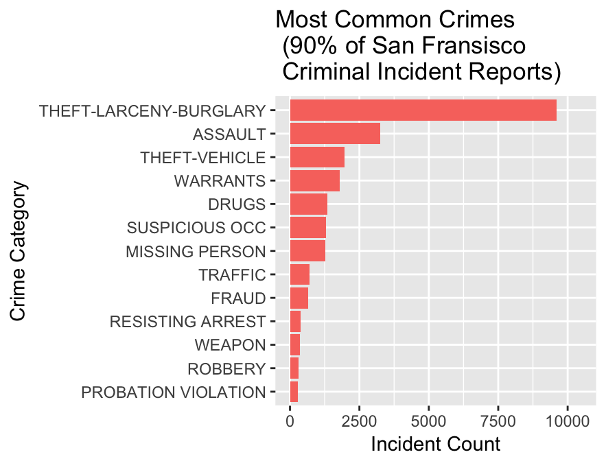

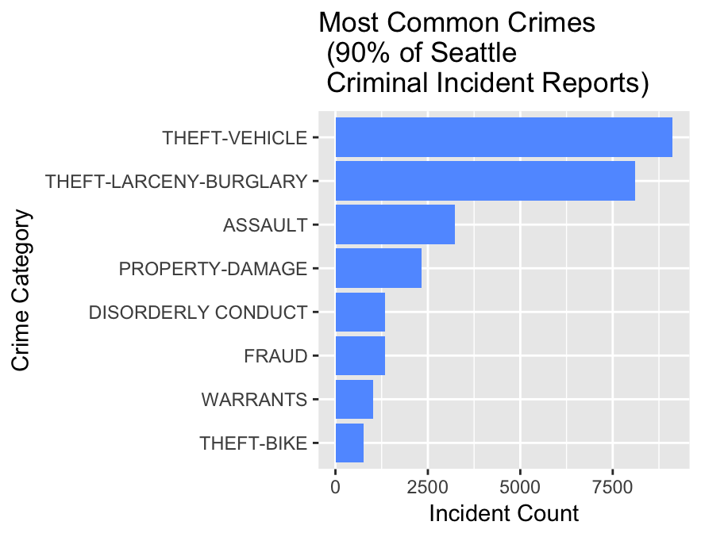

There are some interesting differences between the most common crimes in each of the two cities. In **Seattle** *theft* is by far the most common crime: vehicles mostly (cars, trucks, boats – interestingly bikes have their own category). **Seattle-ites** also like to be rowdy, *property damange* and *disorderly conduct* make the top five.

```r
# per capita
top90_cat <- c(sea_levels90$category, sf_levels90$category)

top90 <- sfsea[which(sfsea$category %in% top90_cat), ]

top90_levels <- top90 %>%
  group_by(
    city,
    category
  ) %>%
  summarize(
    count = n()
  ) %>%
  ungroup %>%
  group_by(
    category
  ) %>%
  filter(
    count == max(count)  # want to arrange the categories in decending order by the max
  ) %>%                  # of the larger city count, not by the total count of both cities.
  ungroup %>%
  arrange(
    count
  )

pop <- data.frame(city = c("San Francisco", "Seattle"), pop = c(852469, 668324))

top90_levels %<>%
  left_join(., pop, by = "city") %>%
  mutate(
    per_capita = count / pop
  ) %>%
  arrange(
    per_capita
  )

top90_sum <- top90 %>%
  group_by(
    city,
    category
  ) %>%
  summarize(
    count = n(),
    pop = mean(pop)
  ) %>%
  mutate(
    per_1000_capita = 1000 * count / pop
  ) %>%
  ungroup

top90_sum$category <- factor(top90_sum$category, levels = top90_levels$category)

both.plot <- top90_sum %>%
  ggplot(
    aes(category, per_1000_capita)
  ) +
  geom_bar(
    aes(fill = city), position = "dodge", stat = "Identity"
  ) +
  coord_flip() +
  labs( y = "Incident Count per 1000 capita", x = "Crime Category", title = "Most Common Crimes \n in San Francisco and Seattle")
```

When looked at per-capita, the two cities show some significant differences and a few anomolies.

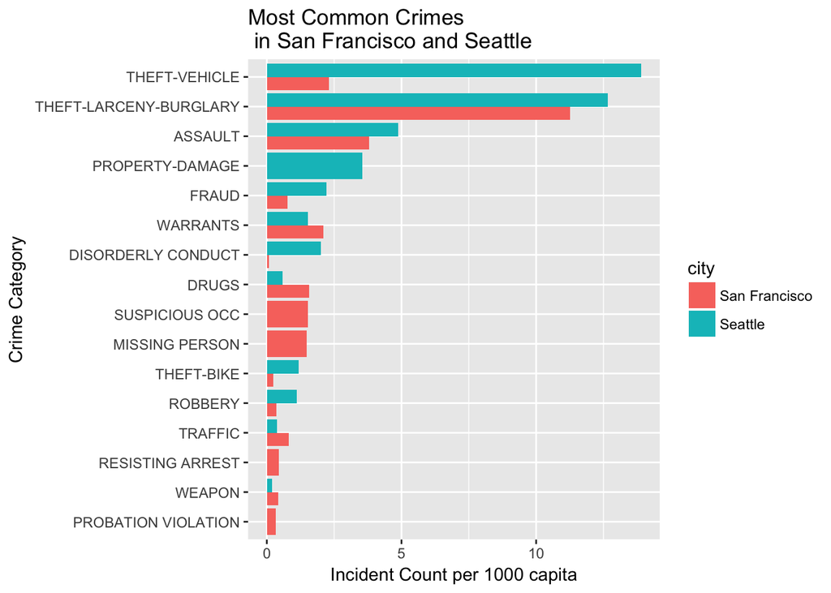

First, Seattle has more theft of all kinds than does San Francisco (over 5x the *vehicle theft*). **Seattle** also has more *assaults* and *robberies* per head over the time period. **San Francisco**, however, has more *warrant arrests* per capita than Seattle.

Interesting, the **San Francisco** data does not include any *property damage* reports. There are *vandalism* reports but the descriptions refer to proximity to highways, while the **Seattle** reports clearly include residential incidents. Perhaps more intesting in the case of *missing persons*, **Seattle** does not seem to have anyone reported missing over the Summer of 2014, whereas **San Francisco** has quite a few. **San Franciscans** also appear to be more suspicious than those in **Seattle** as **Seattle** reports no *suspicious occurances*.

## Crime Sleeps In

```r
# sf
sf_by_hour <- sf_clean90 %>%
  group_by(
    category,
    hour(date)
  ) %>%
  summarize(
    count = n()
  ) %>%
  mutate(
    count = scale(count)
  )


sf_h.plot <- sf_by_hour %>%
  ggplot() +
  geom_line(
    aes(`hour(date)`, count, color = category),
    alpha = 0.3,
    size = 1
  ) +
  geom_smooth(
    aes(`hour(date)`, count)
  ) +
  scale_color_manual(
    values = c("grey70", "blue", "grey70", "grey70",
               "grey70", "red", "grey70", "grey70",
               "grey70", "grey70", "grey70", "grey70",
               "grey70", "grey70", "grey70", "grey70"
    )
      ) +
  labs( x = "Hour of Day", y = "Relative Incident Count", title = "Incident Counts by Time of Day \n for San Francisco")


# sea
sea_by_hour <- sea_clean90 %>%
  group_by(
    category,
    hour(date)
  ) %>%
  summarize(
    count = n()
  ) %>%
  mutate(
    count = scale(count)
  )


sea_h.plot <- sea_by_hour %>%
  ggplot() +
  geom_line(
    aes(`hour(date)`, count, color = category),
    alpha = 0.3,
    size = 1
  ) +
  geom_smooth(
    aes(`hour(date)`, count)
  ) +
  scale_color_manual(
    values = c("grey70", "grey70", "grey70", "blue",
               "grey70", "grey70", "grey70", "grey70",
               "grey70", "grey70", "grey70", "grey70",
               "grey70", "grey70", "grey70", "grey70"
    )
  ) +
  labs( x = "Hour of Day", y = "Relative Incident Count", title = "Incident Counts by Time of Day \n for Seattle") +
  ylim(c(-2, 3))
```

Looking at incidents by time of day shows that contrary to common belief, the dead of night is not when most crimes occur. In fact, in both **San Francisco** and **Seattle** crime does not pick up until after 9 am, peaking in the afternoon/early evening, and then usually calls it a night by 10 or 11 pm.

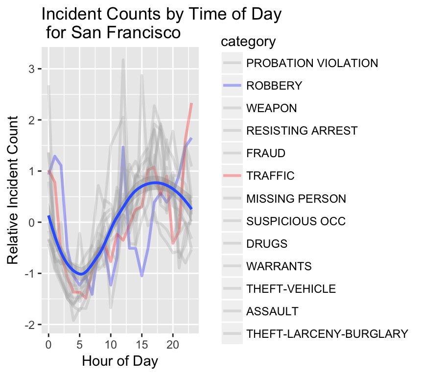

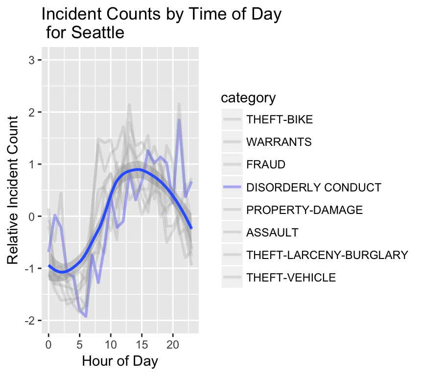

## Crime is Highest in Poorest, Most Visited by Tourists, and Most Densely Populated Parts of Town

```r
counties <- map_data("county")

# SF

ca_county <- subset(counties, region == "california")
sf_county <- subset(ca_county, subregion == "san francisco")
sf_county$long <- sf_county$long - 0.03
sf_county$lat <- sf_county$lat + 0.005

sfm <- ggplot()
sfm <- sfm +
  geom_polygon(
    data = sf_county,
    mapping = aes(x = long,
                  y = lat,
                  group = group),
    fill = "gray"
  ) +
  coord_fixed(1.3) +
  geom_point(data = sf_clean90,
             aes(lon, lat, color = category),
             alpha = 0.1
            ) +
  theme(axis.text.y = element_blank(), axis.text.x = element_blank(),
        panel.grid.major = element_blank(),
        panel.grid.minor = element_blank(),
        panel.background = element_rect(fill = "white"),
        legend.key = element_rect(fill = "white"),
        # legend.position = "bottom",
        axis.ticks = element_line(size = 0)) +
  labs( x = "Longitude", y = "Latitude", title = "Location of Incidents for San Francisco")


# Seattle

sea_clean90_nz <- sea_clean90 %>%
  arrange(
    lon
  ) %>%
  filter(
    lon < -120
  )

wa_county <- subset(counties, region == "washington")
sea_county <- subset(wa_county, subregion == "king")
sea_county$long <- sea_county$long - 0.05
sea_county$lat <- sea_county$lat + 0.006

seam <- ggplot()
seam <- seam +
  geom_polygon(
    data = sea_county,
    mapping = aes(x = long,
                  y = lat,
                  group = group),
    fill = "gray"
  ) +
  coord_fixed(1.3) +
  geom_point(data = sea_clean90_nz,
             aes(lon, lat, color = category),
             alpha = 0.1
  ) +
  theme(axis.text.y = element_blank(), axis.text.x = element_blank(),
        panel.grid.major = element_blank(),
        panel.grid.minor = element_blank(),
        panel.background = element_rect(fill = "white"),
        legend.key = element_rect(fill = "white"),
        # legend.position = "bottom",
        axis.ticks = element_line(size = 0)) +
  coord_cartesian(xlim = c(-122.4253, -122.23), ylim = c(47.46, 47.75), expand = TRUE) +
  labs( x = "Longitude", y = "Latitude", title = "Location of Incidents for Seattle")
```

Plotting each incident’s location shows consentrations in the densest (and lower income) parts of the city. (Grey areas in the maps below indicate county boundaries which may extent over water.)

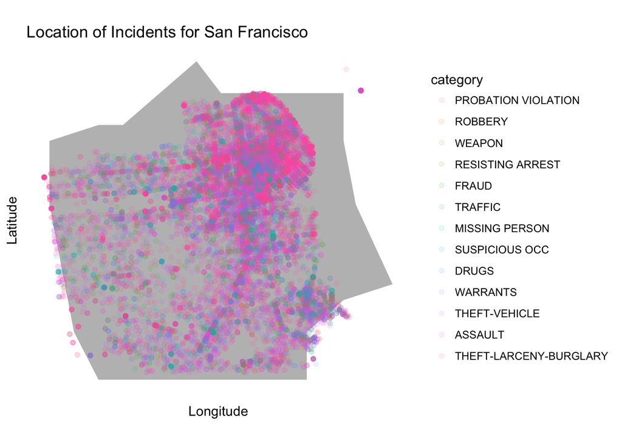

**San Francisco** data shows the highest consentration of crime in the low-income Tenderloin and Mission St. corredor along with the high density North Beach neighborhood. *Theft* (bringt pink) is also consentrated in the tourist areas (Market St. corredor and along the warves).

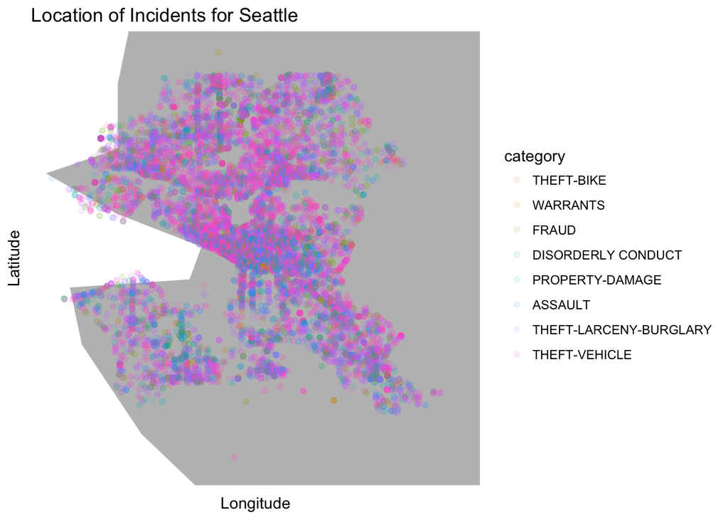

**Seattle** sees the most crime in the Downtown and University District.

## Conclusion

Differences in incident categories and police prorities explain some of the differences between the reported crime levels in **San Francisco** and **Seattle**. However, there still remain differences in the types of crimes most common in each city. But even with the differences in focus by criminals, the levels of crime through the day are similar and are concentrated in the poorer and more dense parts of each city.